# ロサンゼルス研修旅行 2019

浅野ゼミでは毎年、アメリカ主要都市へ研修旅行をしています。2019年度は11月3日～11月9日の7日間、ロサンゼルスを訪問しました。 参加者は、浅野ゼミの2年生と3年生をはじめ、早稲田大学の学生、浅野先生の計19名です。滞在中のプランニングは参加者が個別に行い、グループごとにそれぞれロサンゼルスの様々な場所を訪問しました。短期間ではありましたがとても密度が濃く、身になる研修でした。以下に、主な活動内容を報告します。

[figure not shown]

トランジットの中国国際空港にて

#### 11月3日

15時頃に成田空港からロサンゼルスへ向けて出発し、中国国際空港で乗り換え、17時頃にロサンゼルス空港に到着しました。成田から北京経由でロサンゼルスに向かったため、約16時間の長いフライトで疲れました。LAX到着後、宿泊先であるResort Style Apartment near the UCLA へと空港からUberを手配しアメリカを感じながらホテルへと向かいました。到着が夕方であったため、ホテル近くにあった Denny’s で夕飯を済ませて2日目に備えました。

[figure not shown]

Westwoodのホテルに近い Denny’s

#### 11月4日

この日はまずサンタモニカビーチに向かいました。朝の日差しは気持ちがよく、ビーチは見渡す限り続く美しい砂浜で、すっきりとした気分で二日目をスタートしました。

[figure not shown]

サンタモニカビーチにて

爽やかなビーチを満喫した後、カリフォルニア大学ロサンゼルス校（UCLA: University of California, Los Angeles）を見学しました。建物も景色もとても壮大で日本では考えられないほどの大きさのスケールでした。政治学部のある Bunche Hall で浅野先生の論文発表を見学した後、発表会場で知り合った中国人留学生 Cheung さんに大学構内を案内してもらいました。Cheung さんは 東京大学から UCLA に交換留学している留学生です。色々と為になる話を聞きながら美しい校内を散策しました。

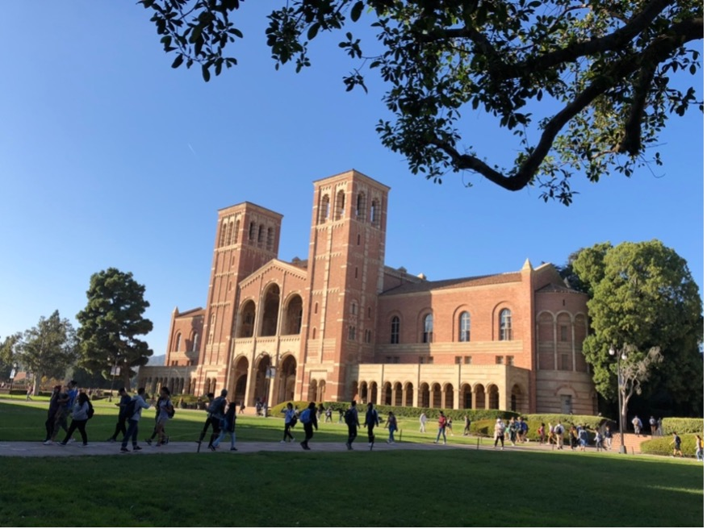

UCLAの名所Royce Hall

[figure not shown]

浅野先生の論文発表会場 (Bunche Hall 10383, UCLA)論文のタイトルは Candidates’ Facial Attractiveness and Electoral Success

#### 11月5日

[figure not shown]

Universal City にて

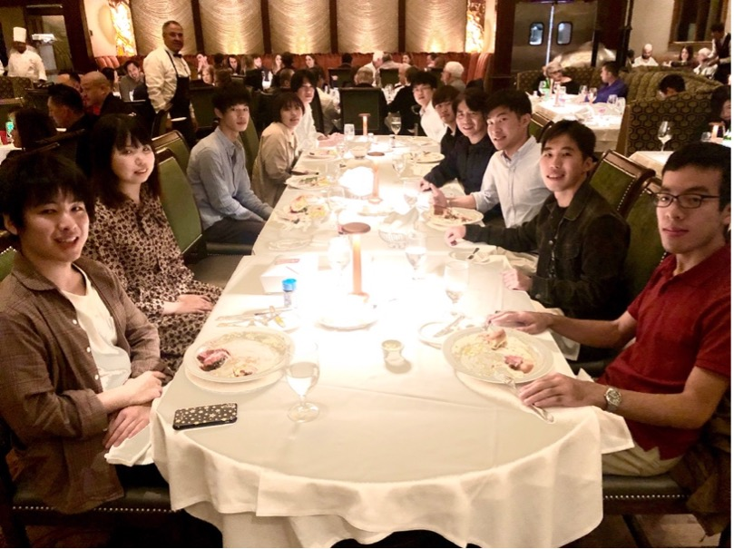

Lawry’s The Prime Rib - Beverly Hillsにて

#### 11月6日

この日は、二年生はハリウッド&ミッドウィルシャーと、映画『La La Land』に出てくるグリフィス天文台グループと、本場のディズニーのテーマパークであるディズニー・カリフォルニアとアドベンチャー・テーマパークのグループに分かれました。三年生は全員で、ハリウッド＆ビバリーヒルズとビバリーセンターに行きました。各々自分達が行きたい所へ行き、ロサンゼルスを堪能しました。 ハリウッド&ミッドウィルシャー・グリフィス天文台グループでは、午前中にハリウッドとミッドウィルシャーを見学し、夕方からはグリフィス天文台に移動しました。グリフィス天文台では、写真では伝わらないロサンゼルスの壮大な夜景を、肉眼で確かめることができました。天文台の中は美術館になっており、太陽系がどのように形成されたのか、生命の誕生などについての展示物がありました。

#### 11月7日

この日は、2年生はセンチュリーシティとサンタモニカを散策した後に射撃を体験し、3年生はグリフィス展望台、ダウンタウンを観光しました。ロサンゼルスでは、物値が安かったので買い物を楽しみました。射撃場では、本物の銃を撃つという得がたい体験をしました。日本ではできない体験で、参加者はその迫力に圧倒されました。グリフィス展望台は、写真でみた景色とは全く別物で、山頂から広大なロサンゼルス全体の夜景を見渡すことができ、そのスケールの大きさと美しさにとても感動しました。ダウンタウンでは、おしゃれなレストランや文化施設があり、街並みがとても綺麗でした。ダウンタウンは様々な人気スポットがあるので、写真と撮って最終日を満喫しました。

[figure not shown]

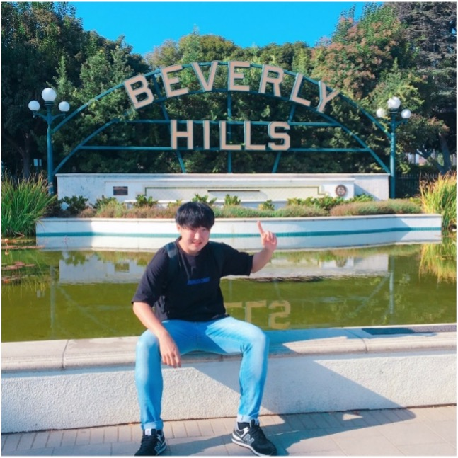

Bevery Hillsにて

文責：小河内 貴幸（おごうち・たかゆき、拓殖大学政経学部2年）

### 参加学生の感想

◎以下は研修旅行に参加した学生たちの感想です。

#### 拓殖大学 政経学部2年 萩原陸

私は、今回ロサンゼルスに行き、たくさんの場所を訪れ、様々な経験をしました。その中で特に感じたのは、私の英語リスニング能力や発音のお粗末さでした。Uberの運転手が私に話しかけてきても、話の内容は断片的にしか聞き取れず、言葉のキャッチボールすらまともに行えませんでした。しかし、今回の研修をつうじて、今後の課題がはっきりと見つけることができたのでとても良い研修でした。また、研修初日と最終日とを比べると、初日では会話が全く出来ませんでしたが、最終日は少し会話ができるようになり、とても良い経験をしたという実感があります。とても充実した1週間でした。またこのような機会があれば積極的に参加していきたいと思います。

#### 拓殖大学 政経学部3年 関駿介

アメリカ研修を通して、私は日本とアメリカの文化の違いについて触れることができ、貴重な体験が出来ました。まずアメリカで驚いたことは、食べ物のサイズ感が全く違うことです。日本人の私たちはすぐにお腹いっぱいになってしまいました。 また、アメリカ人の優しさに気づくことが出来ました。正直、渡米する前は、アメリカ人は怖い人ばかりだと思っていました。しかし、そんなことはありませんでした。私たちが道に迷って困っている時は、丁寧におしえてくれます。そして、英語が不自由な私たちに対して、分かりやすくジェスチャーを交えて教えてくれました。 日本では当たり前にできることが、言葉が異なるアメリカでは全く出来ないことも多々あり、私たちの日頃の生活にも感謝することができるようになりました。これらのアメリカ研修で得た経験を活かし残りの大学生活を豊かにしていきます。

#### 早稲田大学 社会科学部2年 上山敬之

私はアメリカへの渡航は去年度のボストンでの研修に続き、2回目でしたが、前回とは違った体験ができたと思います。UCLAのすぐ近くに滞在したため、綺麗なキャンパスに飽きることなく何度も立ち寄り、学生たちのハイレベルな会話や行動を見聞きしながら、今さらながら自分たちが所詮井の中の蛙に過ぎないことを思い知らされていました。 浅野先生の論文発表の際に偶然知り合ったUCLA Public Policyに東大から交換留学しているCheungさんとの出会いは自分にとって何よりのものであると思います。日本とアメリカ、中国はどこが違うのか、どうしていくべきかなど途方もない会話をしたこともその一つだと思います。多少なりともCheungさんが自分たちに会話のレベルを合わせてくれていたことはわかっていても、このような人たちともっと会話をしてみたい、そのためにもっと英語力と洞察力、知識をつけたいと思いました。 また、移動中のUberでのドライバーとの会話や、窓越しにみた格差社会の様子、圧倒的な物量を誇るアメリカンスタイルの食事なども何一つ無駄のない経験でした。